# Homework

```r
# Load packages
library(ggplot2)
library(ggthemes)
```

## Statistics warm-up

Consider a random variable $X$ with a probability density function

$$f(x) = \frac{c}{\sqrt{x(b-x)}}, \quad 0<x<b.$$
where $c$ is a normalizing constant and $b$ is a parameter.

### Statistics 1

- Find $c$ such that the probability density function is valid.

The area under the curve of the probability density function must be 1.

$$1 = c \int_{0}^b \frac{1}{\sqrt{x(b-x)}} dx$$
Therefore:

$$\frac{1}{c} = \int_{0}^b \frac{1}{\sqrt{x(b-x)}} dx$$

Prepare by factoring:

$$= \int_{0}^b \frac{1}{\sqrt{x} \sqrt{b-x}} dx$$
Integration by Substitution

Define u and du:

$$u = \sqrt{x}$$

$$du = \frac{1}{2\sqrt{x}}dx$$
Substitute:

$$= 2 \int_{0}^b \frac{1}{\sqrt{b-u^2}}du$$
Factor:

$$= \frac{2}{\sqrt{b}} \int_{0}^b \frac{1}{\sqrt{1 - u^2 / b}} du$$
2nd Integration through Substitution

Define:

$$u = \sqrt{b} \sin (s)$$

$$du = \sqrt{b} \cos (s) ds$$
Substitute:

$$\sqrt{1 - u^2 / b} = \sqrt{1 - \sin^2 (s)} = \cos (s)$$

$$s = \sin^{-1} (u / \sqrt{b})$$

$$= 2 \int_0^b 1 ds = 2s \Big|_0^b$$
Substitute back-in for s and then u:

$$= 2 \sin^{-1} (u / \sqrt{b}) \Big|_0^b$$
$$= 2 \sin^{-1} ({\sqrt{x} / \sqrt{b}}) \Big|_0^b$$

Solve from 0 to b:

$$= 2 \sin^{-1} ({\sqrt{b} / \sqrt{b}}) - 2 \sin^{-1} ({\sqrt{0} / \sqrt{b}})$$

$$= 2 \sin^{-1} (1) - 2 \sin^{-1} (0)$$

$$= 2(\pi / 2 - 0)$$
Solution of integral and solving for c:

$$1 / c = \pi$$
Solution:

$$c = \frac{1}{\pi}$$

### Statistics 2

- Find the corresponding cumulative distribution function, $F(x)$ and its inverse $F^{-1}(x)$.

From the first problem above, the PDF is defined as:

$$PDF = f(x) = \frac{1}{\pi}\frac{1}{\sqrt{x(b-x)}}, \quad 0<x<b.$$

The CDF is simply the integral of the PDF above:

$$CDF = F(x) = \int_{0}^x \frac{1}{\pi}\frac{1}{\sqrt{x(b-x)}}dx, \quad 0<x<b.$$
Factoring out the constant c:

$$F(x) = \frac{1}{\pi} \int_{0}^x \frac{1}{\sqrt{x(b-x)}}dx, \quad 0<x<b.$$
We have the same indefinite integral as part 1, therefore skipping ahead to inputing the integral’s limits we have:

$$= \frac{1}{\pi} \Bigg( 2 \sin^{-1} \Bigg( \frac{\sqrt{x}}{\sqrt{b}} \Bigg)
- 2 \sin^{-1} \Bigg( \frac{\sqrt{0}}{\sqrt{b}} \Bigg) \Bigg)$$

Simplify:

$$CDF = F(x) = \frac{2}{\pi} \sin^{-1} \Bigg( \frac{\sqrt{x}}{\sqrt{b}} \Bigg)$$

The inverse of the CDF is the quantile function. The quantile function can be found by solving the CDF for x.

$$\frac{\pi F(x)}{2} = \sin^{-1} \Bigg( \frac{ \sqrt{x} }{ \sqrt{b} } \Bigg)$$
$$\sin \Bigg( \frac{\pi F(x)}{2} \Bigg) = \frac{ \sqrt{x} }{ \sqrt{b} }$$
$$\sin^{2} \Bigg( \frac{\pi F(x)}{2} \Bigg) = \frac{ x }{ b }$$

$$b \sin^{2} \Bigg( \frac{\pi F(x)}{2} \Bigg) = x$$

$$Quantile = F^{-1}(x) = b \sin^{2} \Bigg( \frac{\pi F(x)}{2} \Bigg)$$

Where $F(x)$ is cumulative probability.

### Statistics 3

- Describe a procedure to generate samples distributed according to $X$, given a set of uniformly distributed samples $u_1,\dots,u_n$.

$$f(x) = \frac{1}{\pi}\frac{1}{\sqrt{x(b-x)}}, \quad 0<x<b.$$

1. Create a PDF function with variables x and b:

```r
PDF <- function(x, b){
  (1 / pi) * (1 / sqrt(x * (b - x)))
}
```

2. Generate n uniformly distributed random variables:

```r
# set n to 10 as a test case
n <- 10
# use random uniform distribution generator function
# note default range is 0 to 1
x <- runif(n)
x
```

```
##  [1] 0.1259119 0.5880254 0.9257501 0.5698294 0.6356190 0.7909949 0.8321484
##  [8] 0.8398357 0.5585170 0.7625165
```

```r
# x could alternatively be specified by a pre-determined array
uniform.variables <- c(0.5,1,1.5,2,2.5,3,3.5,4,4.5)
x <- uniform.variables
x
```

```
## [1] 0.5 1.0 1.5 2.0 2.5 3.0 3.5 4.0 4.5
```

3. Feed variables into the PDF function:

```r
PDF(x = x, b = 5)
```

```
## [1] 0.2122066 0.1591549 0.1389218 0.1299495 0.1273240 0.1299495 0.1389218
## [8] 0.1591549 0.2122066
```

### Statistics 4

- Set the seed to 42 and generate 1,000 samples distributed according to $X$ using 1,000 uniformly distributed samples, with $b=5$. Plot a histogram of the resulting samples.

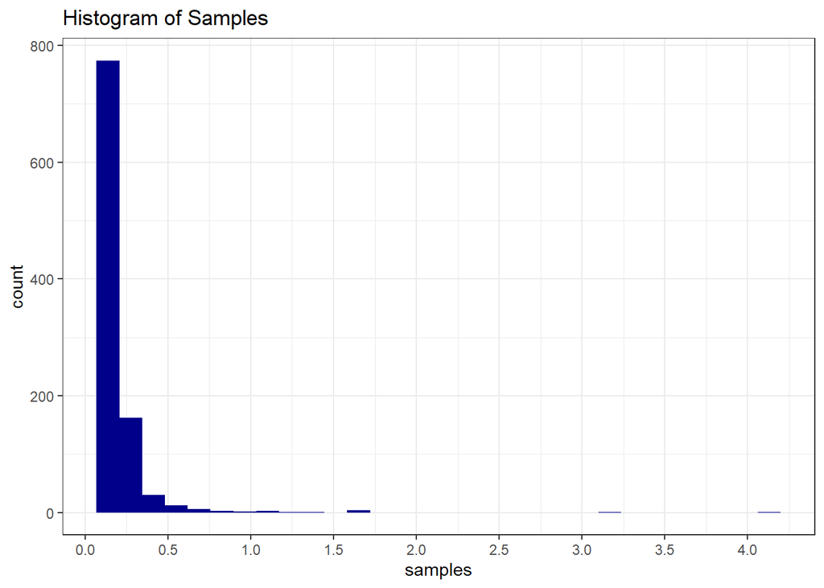

```r
# set seed for consistent generation of the same random numbers
set.seed(42)

# define parameters
n <- 1000
b <- 5

# generate uniform random numbers and input to PDF function to produce samples
# x must be between 0 and b which is 5 therefore pass that to the runif function.
samples <- PDF(x = runif(n, min = 0, max = b), b = b)

# convert sample array to dataframe to prepare for plotting in ggplot
df.samples <- data.frame(samples)

# plot histogram with custom color, theme, title and x axis tick marks
ggplot(df.samples, aes(x=samples)) +
  geom_histogram(fill = "darkblue") +
  ggtitle("Histogram of Samples") +
  scale_x_continuous(breaks = seq(0,5,by=0.5)) +
  theme_bw()
```

### Statistics 5

- Assume that we have a set of samples $X_1,\dots,X_n$ which are i.i.d. as $X$ with $b$ unknown. Find the log-likelihood function for the parameter $b$, $\ell(b;x_1,\dots,x_n)$ and find its derivative with respect to $b$, $\frac{d\ell}{db}$.

The likelihood function for parameter b is as follows:

$$L(b) = \prod_{i=1}^n \Bigg( \frac{1}{\pi \sqrt{X_i (b - X_i)}} \Bigg)$$
The log-likelihood is therefore:

$$LL(b) = \sum_{i=1}^n \Bigg( \log \Bigg( \frac{1}{\pi \sqrt{X_i (b - X_i)}} \Bigg) \Bigg)$$
$$= \sum_{i=1}^n \Big( - \log (\pi) - \frac{1}{2} \log (X_i (b - X_i)) \Big)$$

$$LL(b) = -n \log(\pi) - \frac{1}{2} \sum_{i=1}^n \log(X_i ( b - X_i ) )$$

### Statistics 6

- Based on the likelihood, or otherwise, give a statistic based on $X_1,\dots,X_n$ which is a reasonable estimator for the unknown parameter $b$. Explain your choice.

$$\hat b = LL(b) = \underset{b}{\arg\max} \Bigg( -n \log(\pi) - \frac{1}{2} \sum_{i=1}^n \log(X_i ( b - X_i ) ) \Bigg)$$
Drop terms not containing b and multiplicative constants:

$$= \underset{b}{\arg\min} \Bigg( \sum_{i=1}^n \log(X_i ( b - X_i ) ) \Bigg)$$
Knowing that $0 < x < b$ and treating n as fixed, the summation argument can also be dropped:

$$= \underset{b}{\arg\min} \big( \log(X_i ( b - X_i ) ) \big)$$
A minimized log arguement would be as small as possible while still being positive to make it valid. Therefore:

$$= \underset{b}{\arg\min} \big( X_i ( b - X_i ) \big)$$

Rearranging:

$$= \underset{b}{\arg\min} \big( bX_i - {X_i}^2 ) \big)$$

By inspection we can see that minimizing $b$ yields a minimized function overall. However, we also know for the function to be valid that $X_i < b$. This indicates that $b$ must be larger than the largest $X_i$ value.  
Therefore I select:

$$\hat b \simeq X_{\max} + 1$$

### Statistics 7

- The file `samples.rds` contains samples $X_1,\dots,X_n$ distributed according to $X$. Report the estimated value of $\hat{b}$ based on those samples.

```r
# load R data file
samples7 <- readRDS("data/samples.rds")
head(samples7)
```

```
## [1] 83.68329 84.37033 16.08385 79.29807 60.94930 45.15411
```

```r
# estimate parameter b
b.hat <- max(samples7) + 1
cat("Parameter b is estimated to:", b.hat)
```

```
## Parameter b is estimated to: 86.19952
```

## Arrays

You are given a multi-dimensional array `array.rds`. It contains penetrance curves for various cancers and genes. In simple terms, penetrances are how likely one will develop a cancer given that they have a certain corresponding gene mutation. Other variables in `data` describe different sub-populations. For example, the probabilities corresponding to `Brain` cancer and gene `APC` are the probabilities for which a person will develop brain cancer, given that they have a mutation in the `APC` gene.

### Arrays 1

- Read in the data and give the dimensions of the array.

```r
array.data <- readRDS("data/array.rds")
str(array.data)
```

```
##  num [1:18, 1:26, 1:8, 1:2, 1:94] 3.98e-05 2.80e-07 0.00 5.00e-08 0.00 ...
##  - attr(*, "dimnames")=List of 5
##   ..$ Cancer: chr [1:18] "Brain" "Breast" "Cervical" "Colorectal" ...
##   ..$ Gene  : chr [1:26] "APC" "ATM" "BARD1" "BMPR1A" ...
##   ..$ Race  : chr [1:8] "All_Races" "AIAN" "Asian" "Black" ...
##   ..$ Sex   : chr [1:2] "Female" "Male"
##   ..$ Age   : chr [1:94] "1" "2" "3" "4" ...
```

*Hint: Use the `str` function.*

### Arrays 2

- Subset the array for the penetrances associated with `Breast` cancer and the `BRCA2` gene for a female with the default race `All_Races`. Then plot the penetrance curve (probability versus age).

```r
# Specify patient demographics
Cancer <- "Breast"
Gene <- "BRCA2"
Race <- "All_Races"
Gender <- "Female"

# subset array by specifying 4 of 5 matrix names
sub.array <- array.data[Cancer,Gene,Race,Gender,]

# check the subset head
head(sub.array, 10)
```

```
##        1        2        3        4        5        6        7        8
## 0.00e+00 1.88e-09 1.32e-08 4.00e-08 7.00e-08 1.15e-07 1.71e-07 2.39e-07
##        9       10
## 3.18e-07 7.63e-07
```

```r
# convert the subset array to a data frame for use with ggplot
# convert age to a numeric vector
df.sub.array <- data.frame(as.numeric(names(sub.array)), sub.array)

# set column names in the data frame
colnames(df.sub.array) <- c("Age","Probability")

# check the data frame head
head(df.sub.array)
```

```
##   Age Probability
## 1   1    0.00e+00
## 2   2    1.88e-09
## 3   3    1.32e-08
## 4   4    4.00e-08
## 5   5    7.00e-08
## 6   6    1.15e-07
```

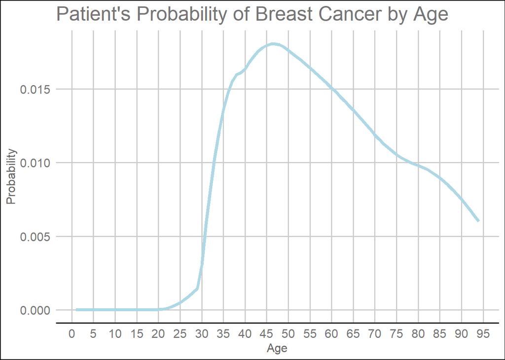

```r
# plot the data on a line graph with custom color, x ticks, title, and theme
ggplot(df.sub.array, aes(x = Age, y = Probability)) +
  geom_line(color = "lightblue", size = 1.5) +
  ggtitle("Patient's Probability of Breast Cancer by Age") +
  scale_x_continuous(breaks = seq(0,95,by=5)) +
  theme_gdocs()
```

### Arrays 3

- Subset the array for the penetrances associated with `Colorectal` cancer and the `PALB2` gene for an Asian male. What is the probability that a person from this subpopulation at age 50 will develop colorectal cancer in the next 10 years given that he has tested positive for a PALB2 mutation but is otherwise disease free?

*Hint: The probability over a period of time is calculated by summing the yearly risks.*

```r
# Specify patient demographics
Cancer <- "Colorectal"
Gene <- "PALB2"
Race <- "Asian"
Gender <- "Male"
pt.age <- 50
risk.window <- 10
future.age <- pt.age + risk.window

# subset array by specifying 4 of 5 matrix names
sub.array2 <- array.data[Cancer,Gene,Race,Gender,]

# This is asking for cumulative probability of patient's age from 0 to age 60
# subset the array again from age 1 to the future.age, then sum the array
# then convert to percentage
cumulative.risk <- sum(sub.array2[seq(1,future.age)]) * 100

# Display Risk:
cat("Patient's Risk of Colorectal Cancer by Age",future.age,"is:",
    cumulative.risk,"%")
```

```
## Patient's Risk of Colorectal Cancer by Age 60 is: 1.1469 %
```

## Family pedigrees

Read in the `.rdata` file `pedigree.rda`. Each `data.frame` represents a family. Each individual is uniquely identified by the first column called `ID`. Their sex is coded as `0` for females and `1` for males. Individuals’ mother and father are indicated in the `MotherID` and `FatherID` columns. A value of `NA` in these columns means that this person is a so-called ‘founder’ or that a certain parent is missing.

```r
# load data
pedigree.data <- load("data/pedigree.rda")
str(pedigree.data)
```

```
##  chr [1:4] "fam10" "fam50" "fam75" "fam100"
```

Each pedigree can be thought of as a family tree. For example, a visualisation of a sample pedigree is shown below. The colours indicate affliction status for cancers as labelled in the legend.

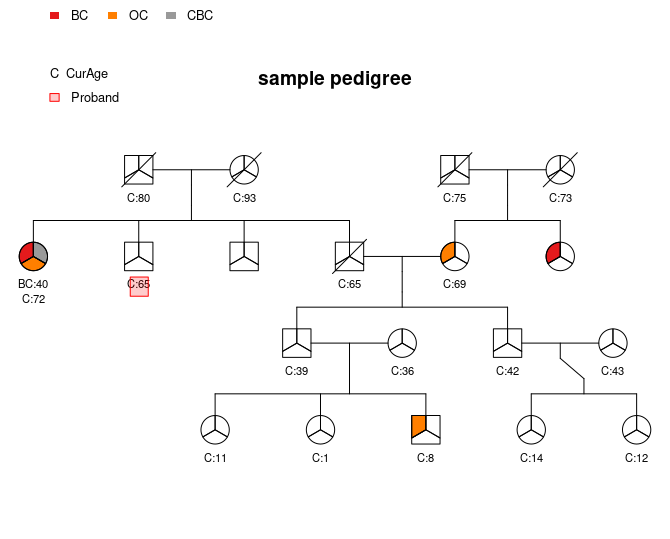

In the following exercises, you are encouraged to modularise and comment on your code.

### Family Pedigrees 1

- Write an R function(s) to count the number of unique nuclear families there are in a certain pedigree. A nuclear family is defined as the set of two parents and all of their children.

```r
# define a function to count unique mother/father pairs in a family
# only input needed is the pedigree
mother.father.combos <- function(fam) {

  # Create data frame of all parent pairs by combining MotherID and FatherID
  Mother.Father <- data.frame(cbind(fam[,3], fam[,4]))
  colnames(Mother.Father) <- c("MotherID", "FatherID")

  # Drop all people with NA parents
  # Founders' nuclear families are already counted by their children
  # A missing parent cannot define a nuclear family
  Mother.Father <- Mother.Father[!(is.na(Mother.Father$MotherID) |
                                     is.na(Mother.Father$FatherID)),]

  # Create Pair column of combined Mother and Father IDs
  Mother.Father$Pair <- paste(Mother.Father$MotherID," , ",
                              Mother.Father$FatherID)

  # count unique parent pairs
  uniq.pairs <- length(unique(Mother.Father$Pair))

  # return number of unique pairs
  uniq.pairs
}

# test case
mother.father.combos(fam100)
```

```
## [1] 26
```

### Family Pedigrees 2

- Report the number of nuclear families for the pedigrees contained in the `.rda` file.

```r
# create master function for summarizing number of nuclear families in a data
# file by pedigree.  Only input is the data file name.
summarize.nuclear.families <- function(pedigree.data){

  # create storage
  pedigree <- as.character()
  nuclear.families <- as.numeric()

  # initialize loop counter
  i = 1

  # loop function over all family trees in the pedigree data
  for( fam in pedigree.data ){

    # record current iteration family id
    pedigree[i] <- fam

    # record count of nuclear family for current iteration
    # use get func. to convert character string to reference data frame object
    nuclear.families[i] <- mother.father.combos(get(fam))

    # advance the counter
    i = i + 1


  }

  # create summary data frame
  nuclear.families.by.pedigree <- data.frame(cbind(pedigree, nuclear.families))

  # function's return value
  nuclear.families.by.pedigree
}

# test
summarize.nuclear.families(pedigree.data)
```

```
##   pedigree nuclear.families
## 1    fam10                4
## 2    fam50               10
## 3    fam75               18
## 4   fam100               26
```